# Axes

Author

Sean

Published

November 25, 2024

### 1. Box plot

- draw a boxplot using `PlantGrowth` dataset.
- `labs()` function is to add title, axis labels, and captions.

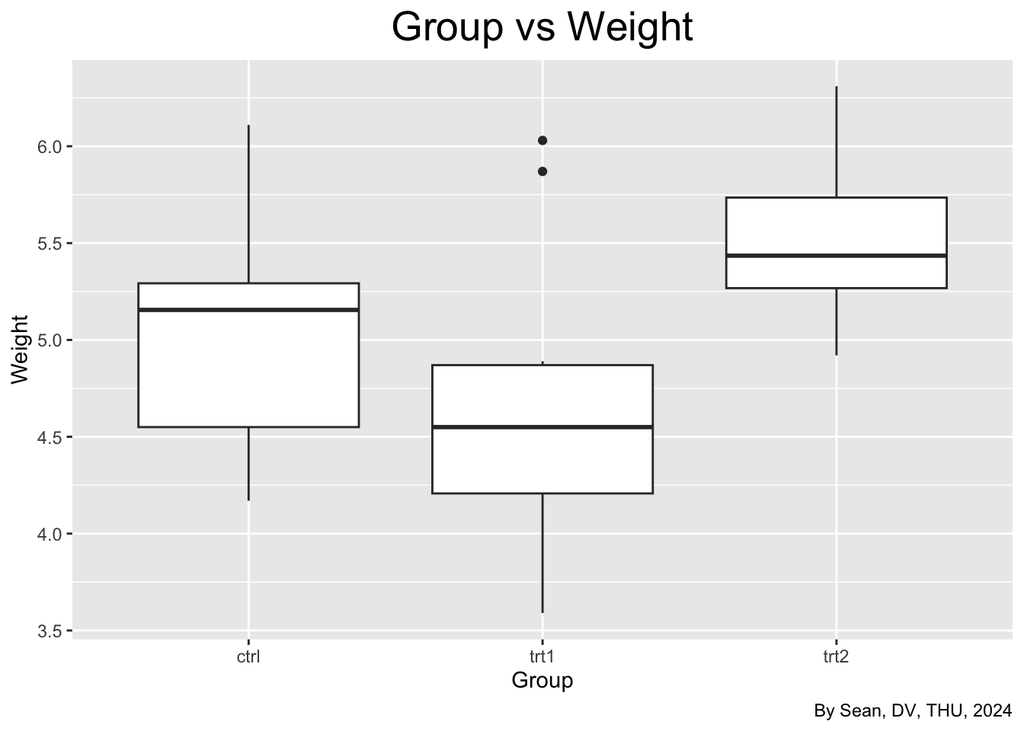

```r
library(ggplot2)
ggplot(PlantGrowth, aes(x = group, y = weight)) +
  geom_boxplot() +
  labs(title = 'Group vs Weight',
       x = 'Group',
       y = 'Weight',
       caption = 'By Sean, DV, THU, 2024') +
  theme(plot.title = element_text(hjust = 0.5, size = 20))
```

### 2. Swap X and Y Axes

- `coord_flip` function is to swap X and Y axes for a transposed view.

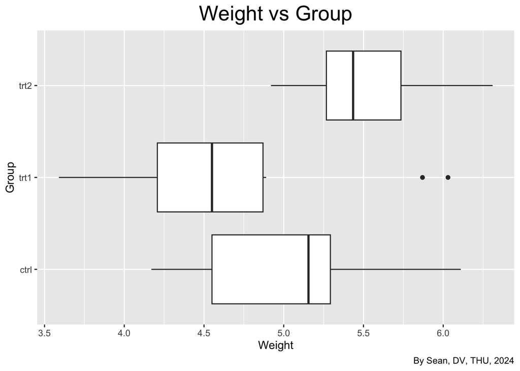

```r
ggplot(PlantGrowth, aes(x = group, y = weight)) +
  geom_boxplot() +
  coord_flip() +
  labs(title = 'Weight vs Group',
       x = 'Group',
       y = 'Weight',
       caption = 'By Sean, DV, THU, 2024') +
  theme(plot.title = element_text(hjust = 0.5, size = 20))
```

### 3. Arrange the Two Plots Side-by-Side

-`grid.arrange` function is to arrange multiple plots side-by-side in one layout.

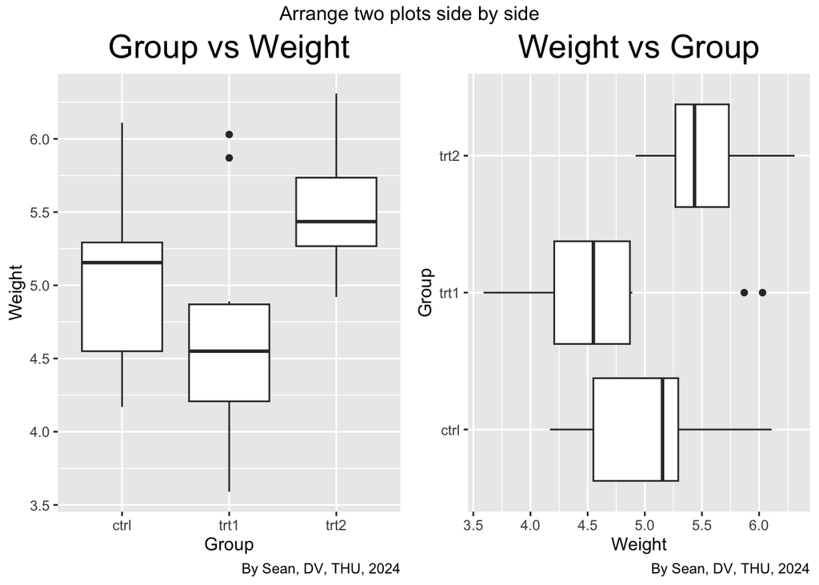

```r
library(gridExtra)

p1 <- ggplot(PlantGrowth, aes(x = group, y = weight)) +
  geom_boxplot() +
  labs(title = 'Group vs Weight',
       x = 'Group',
       y = 'Weight',
       caption = 'By Sean, DV, THU, 2024') +
  theme(plot.title = element_text(hjust = 0.5, size = 20))

p2 <- ggplot(PlantGrowth, aes(x = group, y = weight)) +
  geom_boxplot() +
  coord_flip() +
  labs(title = 'Weight vs Group',
       x = 'Group',
       y = 'Weight',
       caption = 'By Sean, DV, THU, 2024') +
  theme(plot.title = element_text(hjust = 0.5, size = 20))

grid.arrange(p1, p2, ncol = 2,
top = 'Arrange two plots side by side')
```

### 4. Setting the Range of a Continuous Axes

-`ylim(0, max` function is to limit the Y-axis range between 0 and max weight. - `top =`function is to add a title for the combined grid layout.

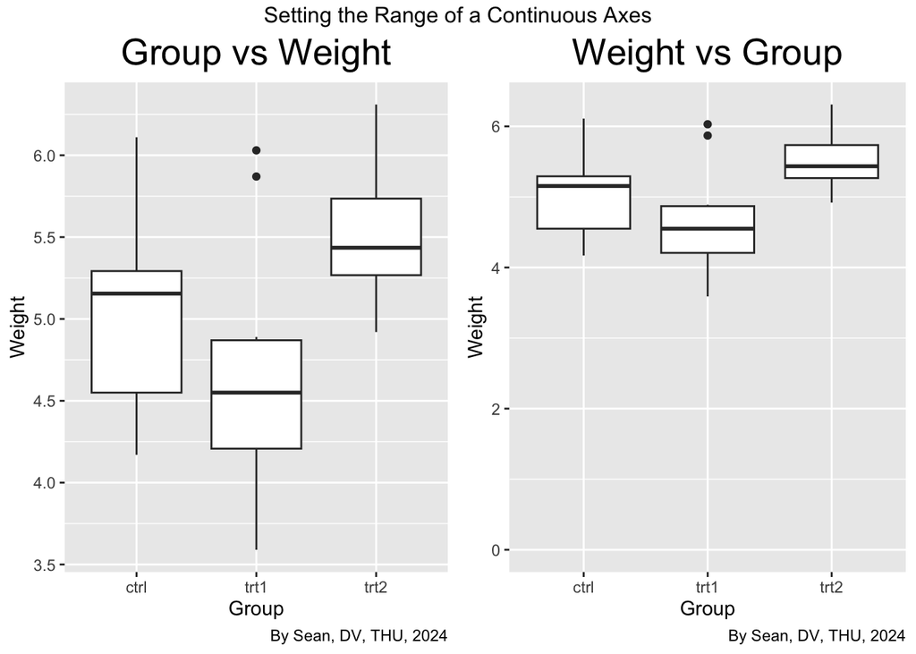

```r
p1 <- ggplot(PlantGrowth, aes(x = group, y = weight)) +
  geom_boxplot() +
  labs(title = 'Group vs Weight',
       x = 'Group',
       y = 'Weight',
       caption = 'By Sean, DV, THU, 2024') +
  theme(plot.title = element_text(hjust = 0.5, size = 20))

p2 <- ggplot(PlantGrowth, aes(x = group, y = weight)) +
  geom_boxplot() +
  ylim(0, max(PlantGrowth$weight)) +
  labs(title = 'Weight vs Group',
       x = 'Group',
       y = 'Weight',
       caption = 'By Sean, DV, THU, 2024') +
  theme(plot.title = element_text(hjust = 0.5, size = 20))

grid.arrange(p1, p2, ncol = 2,
top = 'Setting the Range of a Continuous Axes')
```

### 5. Reversing a Continuous Axes

-`scale_y_reverse()` function is to reverse the direction of the y-axis. (Like from the highest to Lowest and vice-versa)

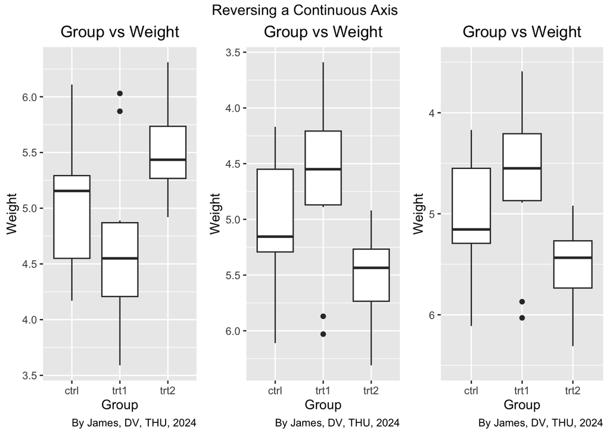

```r
p1 <- ggplot(PlantGrowth, aes(x = group, y = weight)) +
  geom_boxplot() +
  labs(title = 'Group vs Weight',
       x = 'Group',
       y = 'Weight',
       caption = 'By James, DV, THU, 2024') +
  theme(plot.title = element_text(hjust = 0.5))

p2 <- ggplot(PlantGrowth, aes(x = group, y = weight)) +
  geom_boxplot() +
  scale_y_reverse() +
  labs(title = 'Group vs Weight',
       x = 'Group',
       y = 'Weight',
       caption = 'By James, DV, THU, 2024') +
  theme(plot.title = element_text(hjust = 0.5))

p3 <- ggplot(PlantGrowth, aes(x = group, y = weight)) +
  geom_boxplot() +
  scale_y_reverse() +
  ylim(6.5, 3.5) +
  labs(title = 'Group vs Weight',
       x = 'Group',
       y = 'Weight',
       caption = 'By James, DV, THU, 2024') +
  theme(plot.title = element_text(hjust = 0.5))
grid.arrange(p1, p2, p3, ncol = 3,
             top = 'Reversing a Continuous Axis')
```

### 6. Setting the Scaling Ratio of the X- and Y-Axes

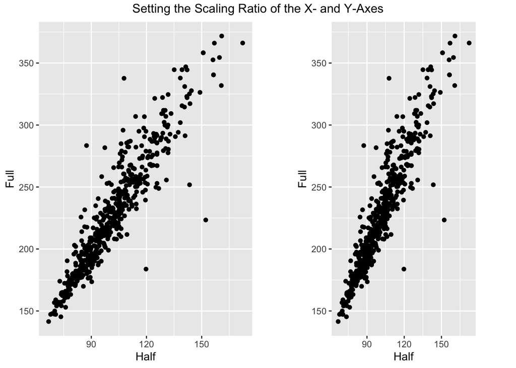

```r
library(gcookbook)

plot1 <- ggplot(marathon, aes(x=Half,y=Full)) +
  geom_point()

plot2 <- ggplot(marathon, aes(x=Half,y=Full)) +
  geom_point() +
  coord_fixed()

grid.arrange(plot1, plot2, ncol=2,
             top = 'Setting the Scaling Ratio of the X- and Y-Axes')
```

### 7. Setting the Scaling Ratio of the X- and Y-Axes

`coord_fixed()` function is to fix the aspect ratio for plot.

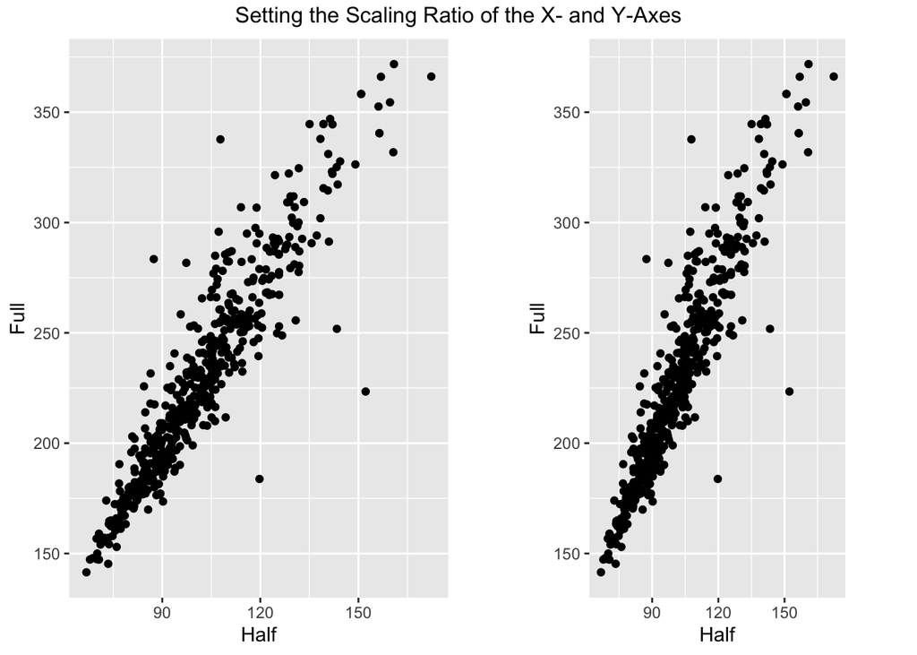

```r
library(gcookbook)

plot1 <- ggplot(marathon, aes(x=Half,y=Full)) +
  geom_point()

plot2 <- ggplot(marathon, aes(x=Half,y=Full)) +
  geom_point() +
  coord_fixed()

grid.arrange(plot1, plot2, ncol=2,
             top = 'Setting the Scaling Ratio of the X- and Y-Axes')
```

### 8. Setting the Positions of Tick Marks

`scale_y_continuous()` function is to control the y-axis if y-axis variable in the plot is continuous

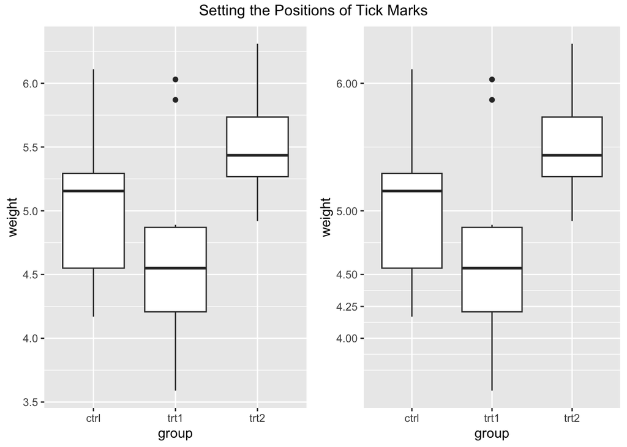

```r
p1 <- ggplot(PlantGrowth, aes(x = group, y = weight)) +
  geom_boxplot()

p2 <- ggplot(PlantGrowth, aes(x = group, y = weight)) +
  geom_boxplot() +
  scale_y_continuous(breaks = c(4, 4.25, 4.5, 5, 6, 8))

# Add title
grid.arrange(p1, p2, ncol = 2,
             top = 'Setting the Positions of Tick Marks')
```

### 9. Removing Tick Marks and Labels

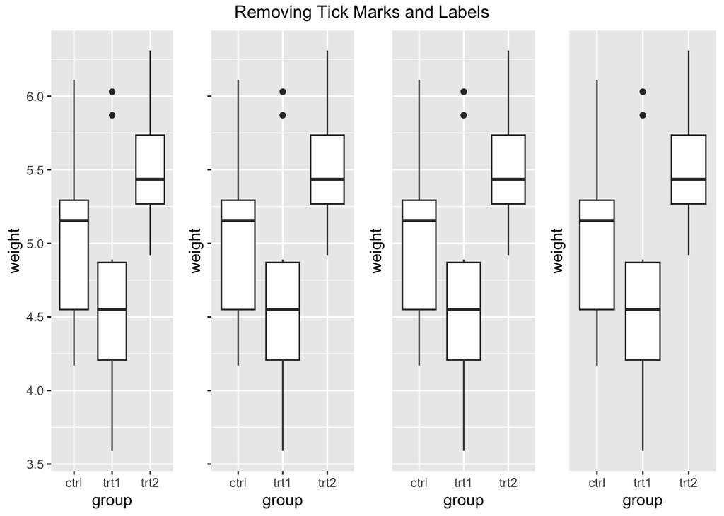

```r
p1 <- ggplot(PlantGrowth, aes(x = group, y = weight)) +
  geom_boxplot()

p2 <- ggplot(PlantGrowth, aes(x = group, y = weight)) +
  geom_boxplot() +
  theme(axis.text.y = element_blank())

p3 <- ggplot(PlantGrowth, aes(x = group, y = weight)) +
  geom_boxplot() +
  theme(axis.ticks = element_blank(), axis.text.y = element_blank())

p4 <- ggplot(PlantGrowth, aes(x = group, y = weight)) +
  geom_boxplot() +
  scale_y_continuous(breaks = NULL)

grid.arrange(p1, p2, p3, p4, ncol = 4,
             top = 'Removing Tick Marks and Labels')
```

### 10. Changing the Text of Tick Labels

- `breaks` is to specify the locations of the tick marks and labels on the y-axis. This results ion a more easier visualization to read.

`labels` function is for customizing the text labels, so you can input the right label for each units.

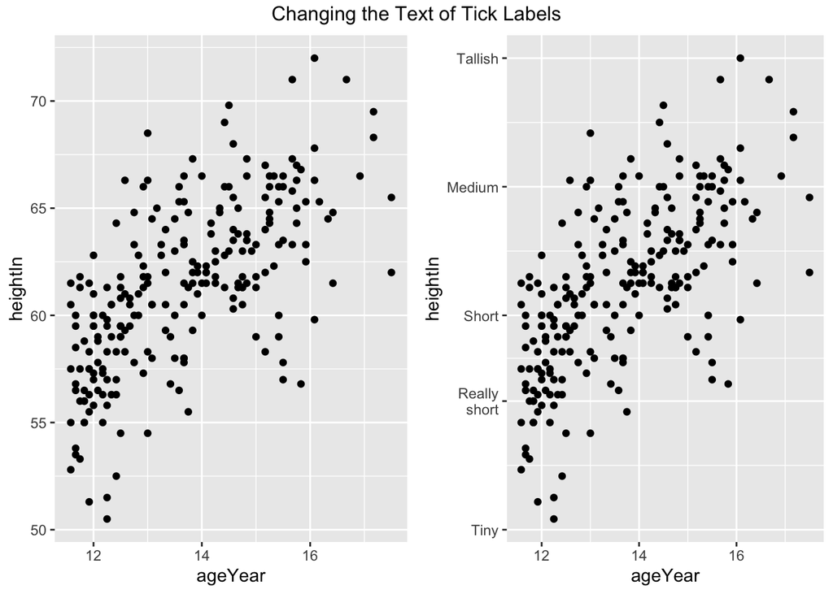

```r
library(gcookbook)

p1 <- ggplot(heightweight, aes(x = ageYear, y = heightIn)) +
  geom_point()

p2 <- ggplot(heightweight, aes(x = ageYear, y = heightIn)) +
  geom_point() +
  scale_y_continuous(
    breaks = c(50, 56, 60, 66, 72),
    labels = c("Tiny", "Really\nshort", "Short", "Medium", "Tallish")
  )

# Add title
grid.arrange(p1, p2, ncol = 2,
             top = 'Changing the Text of Tick Labels')
```

### 11. Lower Tallish to include 6 people

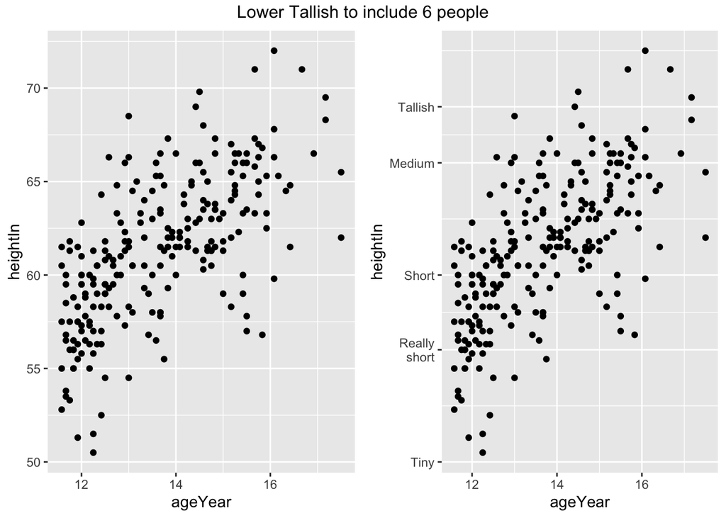

```r
p1 <- ggplot(heightweight, aes(x = ageYear, y = heightIn)) +
  geom_point()

p2 <- ggplot(heightweight, aes(x = ageYear, y = heightIn)) +
  geom_point() +
  scale_y_continuous(
    breaks = c(50, 56, 60, 66, 69),
    labels = c("Tiny", "Really\nshort", "Short", "Medium", "Tallish")
  )

# Add title
grid.arrange(p1, p2, ncol = 2,
             top = 'Lower Tallish to include 6 people')
```

### 12. Changing the Appearance of Tick Labels

-`axis.text.x = element_text(...)` ia to specify targets the text elements of the x-axis.

`angle = 30` means it will rotate the x-axis labels by (30) degrees.

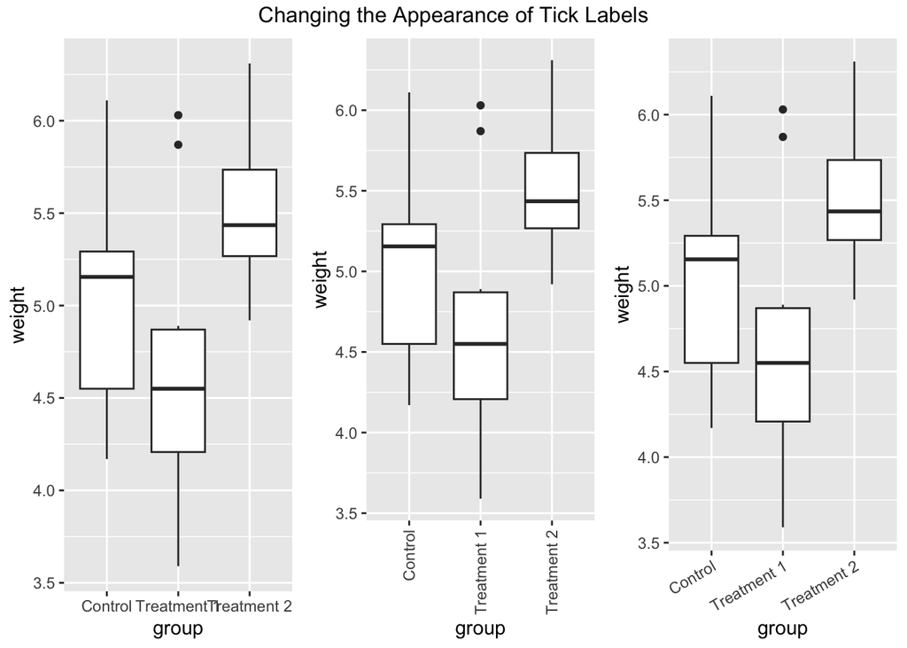

```r
pg_plot <- ggplot(PlantGrowth, aes(x = group, y = weight)) +
  geom_boxplot() +
  scale_x_discrete(
    breaks = c("ctrl", "trt1", "trt2"),
    labels = c("Control", "Treatment 1", "Treatment 2")
  )
p1 <- pg_plot
p2 <- pg_plot +
  theme(axis.text.x = element_text(angle = 90, hjust = 1, vjust = .5))
p3 <- pg_plot +
  theme(axis.text.x = element_text(angle = 30, hjust = 1, vjust = 1))

grid.arrange(p1, p2, p3, ncol = 3,
             top = 'Changing the Appearance of Tick Labels')
```

### 13. Changing the Text of Axis Labels

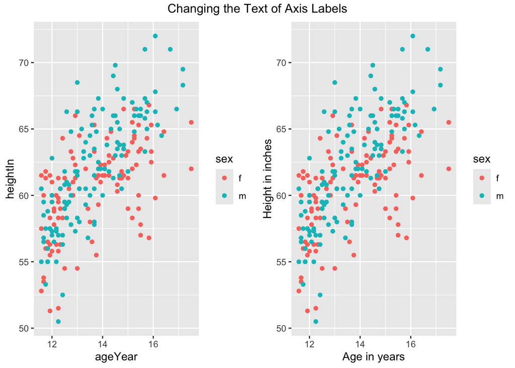

```r
hw_plot <- ggplot(heightweight, aes(x = ageYear, y = heightIn, colour = sex)) +
  geom_point()

p1 <- hw_plot
p2 <- hw_plot +
  xlab('Age in years') +
  ylab('Height in inches')

grid.arrange(p1, p2, ncol = 2,
             top = 'Changing the Text of Axis Labels')
```

### 14. Removing Axis Labels

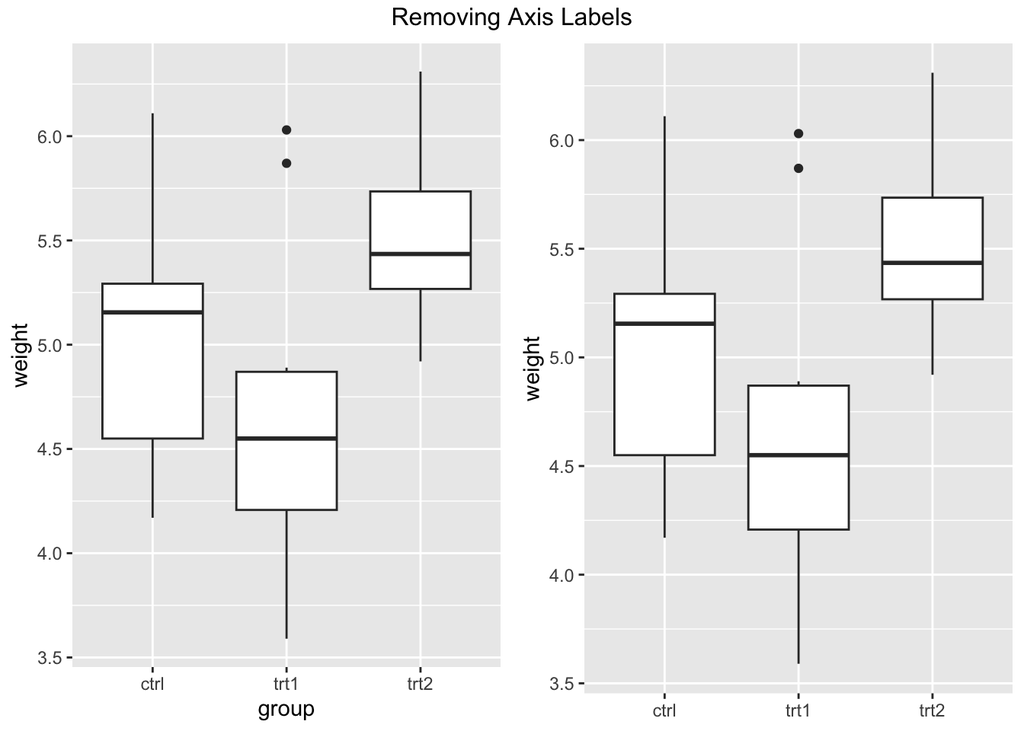

```r
p1 <- ggplot(PlantGrowth, aes(x = group, y = weight)) +
  geom_boxplot()

p2 <- p1  +
  xlab(NULL)

grid.arrange(p1, p2, ncol = 2,
             top = 'Removing Axis Labels')
```

### 15. Changing the Appearance of Axis Labels

-`axis.title.x = element_text(...)` is to specify that we modifythe x-axis title.

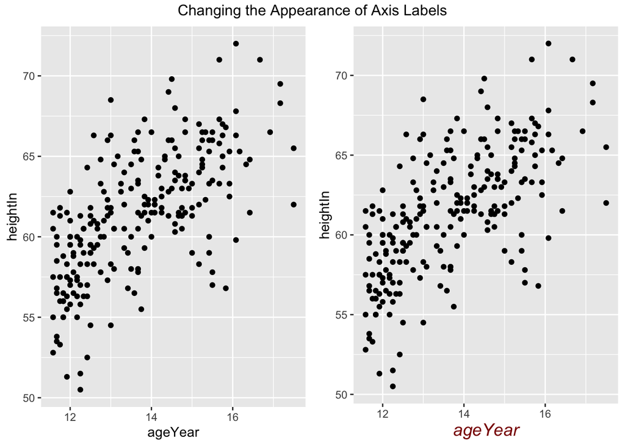

```r
p1 <- ggplot(heightweight, aes(x = ageYear, y = heightIn)) +
  geom_point()
p2 <- p1 +
  theme(axis.title.x = element_text(face = "italic", colour = "darkred",
                                    size = 14))
grid.arrange(p1, p2, ncol = 2,
             top = 'Changing the Appearance of Axis Labels')
```